# A Molecular Mechanical Perspective of Polychlorinated Biphenyls

#### Computational Chemistry Chris Harris 15 Nov 2003 Molecular Modeling techniques have been applied to a series of Polychlorinated Biphenyls. Conformational geometry of the phenyl rings will come under scrutiny, which some have speculated to be coplanar. The results produced in this study support X-ray diffraction data showing a vast divergence in the coplanarity of biphenyl and its chlorinated counterparts, especially for chlorines in the ortho positions. In addition, the rotational barrier for 2,3,4,3’,4’-pentachlorobiphenyl has been calculated to be 11.11 kcal/mol. Polychlorinated Biphenyls ( PCBs ), have been singled out by biologists as having deleterious effects on the environment, due to coplanarity of the phenyl rings[1]. The prototypical chemical structure contains: *2,3,3’,4,4’-pentachlorobiphenyl* two phenyl rings attached to the number one carbon. Beyond that, chlorines may populate any hydrogen position, yielding a chemical formula, C<sub>12</sub>H<sub>10-n</sub>Cl<sub>n</sub>. To differentiate between chlorine locations, carbon positions are arranged in numerical order, with the primary ring first, followed by the secondary ring, featuring primes. For instance, in this study, we will focus on 2,3,3’,4,4’-pentachlorobiphenyl. To give a sense of the discontinuity between structure and description in the literature, here is an excerpt from a report issued by the World Health Organization[2]: *“Unlike the dioxins or dibenzofurans, the phenyl rings of a PCB are not constrained through ring fusions and have relatively unconstrained rotational freedom. Chlorines at the ortho (2,2’, 6,6’) positions introduce constraints on rotational freedom that can hinder coplanarity of the phenyl rings. X-ray crystallographic studies (McKinney & Singh, 1981) indicate that the preferred conformation for all PCBs, including those without ortho-substituents, is noncoplanar. The proportion of molecules of a particular congener assuming a coplanar configuration becomes increasingly small as the degree of ortho-substitution and the energetic cost of conforming increases. However, PCBs without ortho-substitution are often referred to in the biological literature as the planar (or coplanar) PCBs and all others as the nonplanar (or noncoplanar) PCBs. This terminology, though somewhat misleading, is also used throughout this publication for convenience and ease of referring back to the published literature. It is widely recognized that certain biological activities of the PCBs vary, at least quantitatively, with stereochemical differences in the congeners.”* With the stage set, let’s use PC Model, a molecular modeling software, to see if it supports the conformational data expressed in the above statement. Beginning with 2,3,4,3’,4’-pentachlorobiphenyl, I removed one chlorine at a time, minimizing the structure with the MMX force field, then performed a conformational search about the 1-1’ carbon bond to find the lowest energy conformer. Once that conformer was found, I could then determine the dihedral angle. To elucidate the rotational barrier in the pentachloro specie, I took advantage of PC Model’s Dihedral Driver, which systematically rotates a molecule about a particular bond, then minimizes that structure with its force field. **Figure 1**: Pentachlorobiphenyl Dihedral Energy Curve, kcal/mol vs deg **Table 1**: Minimum Strain Energy and Dihedral Angle *Species* *Strain Energy* *Dihedral Angle* 2,3,4,3’,4’-pentachlorobiphenyl 35.26 kcal/mol 118.3 deg 3,4,3’,4’-tetrachlorobiphenyl 30.95 139.1 4,3’,4’-trichlorobiphenyl 26.33 139.2 3’,4’-dichlorobiphenyl 26.96 139.2 4’-monochlorobiphenyl 22.58 139.4 biphenyl 23.43 139.4 In Table 1, the strain energy applies to the 1-1’ carbon bond, which PC Model minimizes, under the influence of the MMX force field, to provide a reference frame for energy comparison. In general, a dihedral angle defines the angle between two planes: *Dihedral angle* For our purposes, it represents the angle between the two planar phenyl rings. Although I was unaware of the World Health Organization’s report at the time of the modeling, I rationalized that the chlorine closest to the 1-1’ carbon bond was most likely to influence the dihedral angle. However, I was rather surprised that none of the other chlorines changed the conformation beyond the first ortho chlorine in the series. My other expectation was that the strain energy would progressively go down with chlorine removal. In contrast to the ortho and meta positions in the phenyl ring, it appears that the chlorines in the para positions stabilize the PCB molecule slightly. In terms of rotational barrier, figure 1 shows that coplanarity, at 0, 180, 360 degrees, represents the maximum energy on the conformational landscape, and thus would cost 11.11 kcal/mol. Therefore, it is highly unlikely that PCBs would be stable, or that a large proportion of conformers, would take on the coplanar configuration. Consistent with a report issued by the World Health Organization, ortho substituted chlorines inhibit planarity between phenyl rings. In the absence of chlorines, biphenyl’s dihedral angle measures over 40 degrees away from planarity. Although none of the calculations or X-ray data supports coplanarity, environmental factors and catalytic activity could influence the outcome, as PCBs circulate through the air, soil, and water. Intuitively, one might image a robust carbon pi network, with delocalized, stable valence orbitals, under a coplanar model, with a conduction band for electrons, as observed in graphite. Perhaps a conductivity study of PCB mixtures found throughout the biosphere, in parallel with calibrated samples, to characterize the problem. [[1]](https://www.nap.edu/read/10041/chapter/4) John W. Farrington, et al., A Risk-Management Strategy for PCB-Contaminated Sediments, National Academy Press: Washington, DC (2001). [[2]](http://www.inchem.org/documents/ehc/ehc/ehc140.htm) S. Dobson, et al., Polychlorinated biphenyls and terphenyls, 2nd ed, World Health Organization: Geneva, Switzerland (1993).

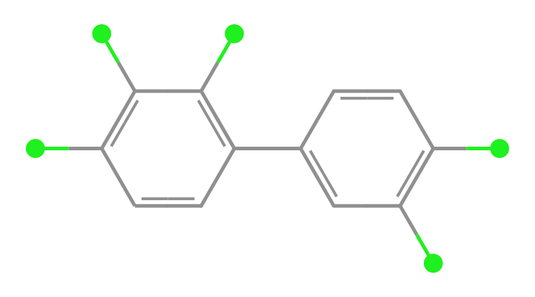

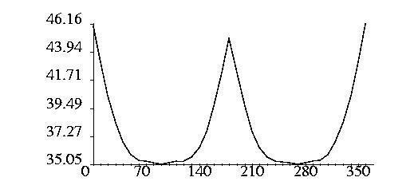

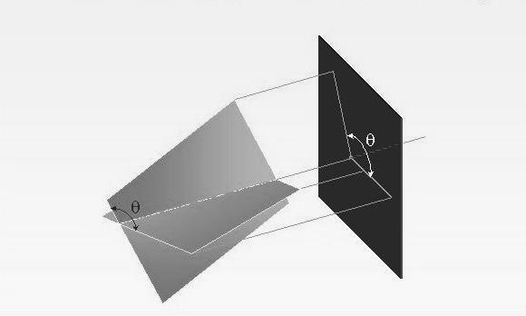